# Machine learning with IMDB

TODO:

- Set aside some films that you’re interested in seeing the prediction and remove them from the dataset.

```r
library(tidyverse)
library(caret)
library(tidytext)
library(splitstackshape)
library(xgboost)
library(rpart)
library(doParallel)
```

```r
data <- read_csv("data/movies.csv")
```

# EDA

Do score distributions differ between IMDB and Metacritic.

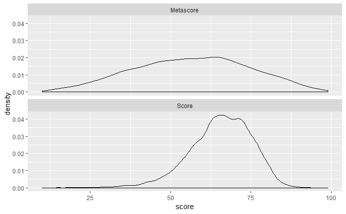

```r
data %>% drop_na(Metascore) %>% mutate(Score = Score *10) %>% gather("score_type", "score", Score, Metascore) %>%
  ggplot(aes(x = score)) +
  geom_density() +
  facet_wrap(~ score_type, ncol = 1)
```

Are genres scored differently?

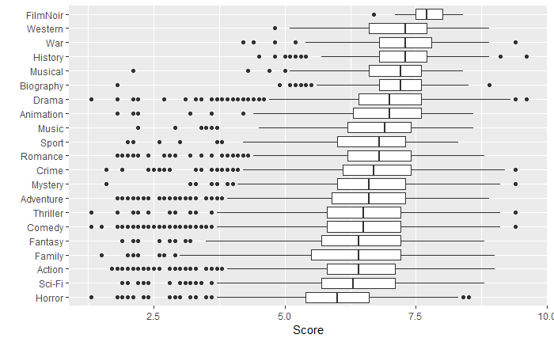

```r
data_genre <- data %>% separate_rows(Genre, sep = ", ")

data_genre %>%
  ggplot(aes(x = fct_reorder(Genre, Score), y = Score)) +
  geom_boxplot() +
  coord_flip() +
  xlab("")
```

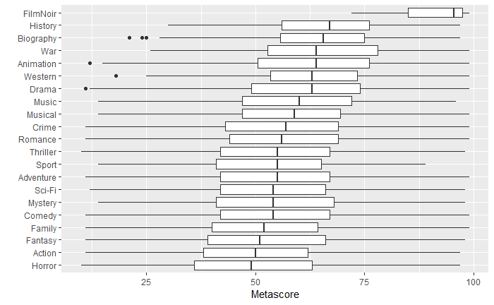

```r
data_genre %>% drop_na(Metascore) %>%
  ggplot(aes(x = fct_reorder(Genre, Metascore), y = Metascore)) +
  geom_boxplot() +
  coord_flip() +
  xlab("") +
  ylab("Metascore")
```

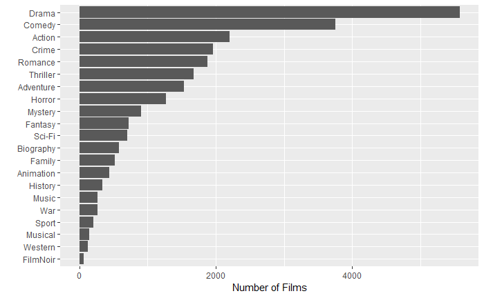

```r
data_genre %>% group_by(Genre) %>% summarise(n = n()) %>%
  ggplot(aes(x = fct_reorder(Genre, n), y = n)) +
  geom_bar(stat = "identity") +
  coord_flip() +
  xlab("") +
  ylab("Number of Films")
```

Do scores change with year of release?

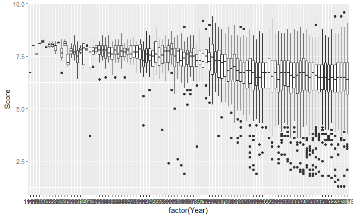

```r
data %>% ggplot(aes(x = factor(Year), y = Score)) +
  geom_boxplot()
```

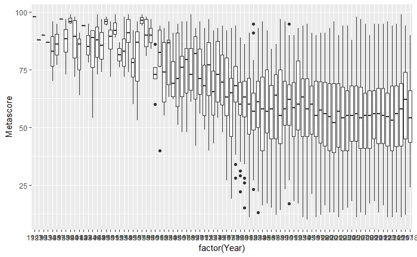

```r
data %>% drop_na(Metascore) %>%
  ggplot(aes(x = factor(Year), y = Metascore)) +
  geom_boxplot()
```

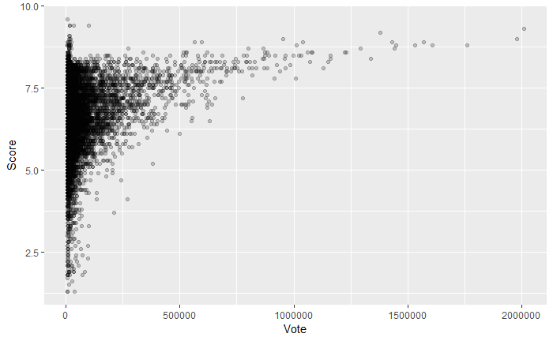

```r
data %>% ggplot(aes(x = Vote, y = Score)) +
  geom_point(alpha = 0.2)
```

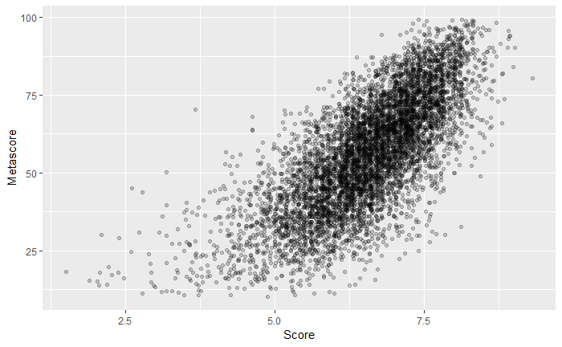

```r
data %>%  drop_na(Metascore) %>%
  ggplot(aes(x = Score, y = Metascore)) +
  geom_jitter(alpha = 0.2)
```

How do words in the description influence score?

```r
data_desc <- data %>% separate_rows(Description, sep = " ")

# Remove "." and ","
data_desc$Description <- gsub("\\.|,", "", data_desc$Description)
data_desc$Description <- ifelse(data_desc$Description == "", NA, data_desc$Description)
data_desc <- data_desc %>% drop_na(Description)

# Change all words to lower (no duplicates for sentence start words)
data_desc$Description <- tolower(data_desc$Description)
```

The data is now pretty clean. I’m going to want to know which words are associated with good movies in the description. I’m going to want to minimise the influence of individual movies, therefore I’m going to want to have general words, not names referring to specific movies. I’ll play around with the cutoff.

```r
data_desc %>% count(Description) %>% arrange(desc(n))
```

| Description | n |
| --- | --- |
| a | 16182 |
| the | 11830 |
| to | 8553 |
| of | 7400 |
| and | 6563 |
| in | 5338 |
| his | 4498 |
| is | 3147 |
| an | 2760 |
| with | 2646 |

[output cut: 990 more lines]

```r
data_desc %>% filter(Description %in% c("his", "her", "boy", "girl", "man", "woman")) %>% group_by(Description) %>%
  summarise(n = n(), mean_score = mean(Score), median_score = median(Score))
```

| Description | n | mean_score | median_score |
| --- | --- | --- | --- |
| boy | 280 | 6.806071 | 7.0 |
| girl | 388 | 6.661856 | 6.7 |
| her | 2211 | 6.545907 | 6.6 |
| his | 4498 | 6.694197 | 6.8 |
| man | 953 | 6.749108 | 6.9 |
| woman | 691 | 6.625470 | 6.7 |

```r
data_desc_cut <- data_desc %>% group_by(Description) %>% summarise(n = n()) %>% filter(n > 29)
data_desc_cutoff <- data_desc %>% semi_join(data_desc_cut)
data_desc_cutoff %>% group_by(Description) %>% summarise(n = n(), mean_score = mean(Score), median_score = median(Score)) %>%
  arrange(desc(mean_score))
```

| Description | n | mean_score | median_score |
| --- | --- | --- | --- |
| jewish | 49 | 7.410204 | 7.40 |
| poor | 46 | 7.378261 | 7.50 |
| i | 30 | 7.343333 | 7.40 |
| conflict | 37 | 7.275676 | 7.40 |
| nazi | 45 | 7.266667 | 7.30 |
| german | 75 | 7.228000 | 7.40 |
| indian | 49 | 7.224490 | 7.50 |
| ii | 99 | 7.218182 | 7.30 |
| ordinary | 30 | 7.183333 | 7.40 |
| growing | 37 | 7.151351 | 7.10 |

[output cut: 990 more lines]

Question: How negative are the words in the descriptions? Are negative words associated more with higher score. I’ll use the BING dictionary for this purpose.

```r
bing <- sentiments %>% filter(lexicon == "bing")
bing <- bing %>% rename(Description = word)

data_desc_sent <- data_desc %>% inner_join(bing)
```

What is the ratio of positive and negative words?

```r
data_desc_sent %>% group_by(sentiment) %>% summarise(n = n(), mean_score = mean(Score))
```

| sentiment | n | mean_score |
| --- | --- | --- |
| negative | 13854 | 6.619215 |
| positive | 6732 | 6.672683 |

According to BING, there are twice as many negative words than positive. How does this compare to BING’s ratio? The negative, positive word association is not significant I don’t think. Therefore, it doesn’t matter if negative or positive words are used in the description by and large.

```r
bing %>% group_by(sentiment) %>% summarise(n = n())
```

| sentiment | n |
| --- | --- |
| negative | 4782 |
| positive | 2006 |

There are actually twice as many negative words than positive. This is indeed tricky to tell.

Do genres have a different ratio of positive and negative words?

```r
data_desc_sent %>% separate_rows(Genre, sep = ", ") %>% group_by(Genre, sentiment) %>% summarise(n = n(), mean_score = mean(Score))
```

| Genre | sentiment | n | mean_score |
| --- | --- | --- | --- |
| Action | negative | 3401 | 6.402705 |
| Action | positive | 1426 | 6.443478 |
| Adventure | negative | 2038 | 6.530422 |
| Adventure | positive | 1125 | 6.597778 |
| Animation | negative | 559 | 6.915385 |
| Animation | positive | 327 | 6.873089 |
| Biography | negative | 587 | 7.184157 |
| Biography | positive | 462 | 7.187662 |
| Comedy | negative | 4480 | 6.451027 |
| Comedy | positive | 2838 | 6.489500 |

[output cut: 32 more lines]

In Thrillers, Sport and Sci-Fi movies the score appears to be positively associated with positive words.

# Machine Learning

Ok, here’s the idea. How well can you predict Metacritic scores of films that don’t have a Metacritic score?

```r
data_genre <- as.data.frame(data_genre)
train <- sample_n(data_genre, nrow(data_genre))
train <- data_genre %>% drop_na(Metascore) %>% spread(Genre, Genre)
titles_train <- train$Title
train <- train %>% select(-Description, -Title, -Rank, -Director)

genres <- train[, 7:27]

genres[!is.na(genres)] <- 1
genres[is.na(genres)] <- 0
genres <- as.data.frame(unclass(genres))

train <- cbind(train[,1:6], genres)
```

This works absolutely great. Amazing stuff.

Ok, the director won’t go there because if a new director comes up, they won’t be properly regressed.

```r
train_x <- train %>% select(-Metascore)
train_y <- train$Metascore
```

Time to train the model.

| eta | max_depth | gamma | colsample_bytree | min_child_weight | subsample | nrounds | RMSE | Rsquared | MAE | RMSESD | RsquaredSD | MAESD |
| --- | --- | --- | --- | --- | --- | --- | --- | --- | --- | --- | --- | --- |
| 0.3 | 3 | 0 | 0.6 | 1 | 0.75 | 100 | 15.49222 | 0.2588789 | 12.61716 | 0.2811733 | 0.03286337 | 0.2752392 |
| 0.3 | 3 | 0 | 0.8 | 1 | 0.75 | 100 | 15.50442 | 0.2580387 | 12.63465 | 0.2977499 | 0.03183222 | 0.2767510 |
| 0.3 | 3 | 0 | 0.6 | 1 | 0.75 | 150 | 15.54735 | 0.2550331 | 12.63684 | 0.2918077 | 0.03362082 | 0.3018358 |
| 0.3 | 3 | 0 | 0.8 | 1 | 0.75 | 50 | 15.46694 | 0.2598043 | 12.63729 | 0.2816353 | 0.03236547 | 0.2743031 |
| 0.3 | 3 | 0 | 0.6 | 1 | 0.75 | 50 | 15.47969 | 0.2587071 | 12.63977 | 0.2681788 | 0.03124518 | 0.2576423 |
| 0.3 | 3 | 0 | 0.6 | 1 | 1.00 | 50 | 15.47545 | 0.2586608 | 12.64587 | 0.2636691 | 0.03257496 | 0.2396930 |
| 0.3 | 3 | 0 | 0.6 | 1 | 1.00 | 150 | 15.53408 | 0.2552165 | 12.65417 | 0.2989044 | 0.03440981 | 0.2686405 |
| 0.3 | 3 | 0 | 0.8 | 1 | 1.00 | 100 | 15.51625 | 0.2558189 | 12.65447 | 0.2873793 | 0.03361787 | 0.2822235 |
| 0.3 | 3 | 0 | 0.6 | 1 | 1.00 | 100 | 15.50739 | 0.2567805 | 12.65502 | 0.2627693 | 0.03214784 | 0.2384367 |
| 0.3 | 3 | 0 | 0.8 | 1 | 1.00 | 50 | 15.50283 | 0.2562725 | 12.65677 | 0.2582884 | 0.03168395 | 0.2501238 |

[output cut: 98 more lines]

| title | metascore | predicted | score | Year | Score | Vote | Runtime | Revenue | Action | Adventure | Animation | Biography | Comedy | Crime | Drama | Family | Fantasy | FilmNoir | History | Horror | Music | Musical | Mystery | Romance | Sci.Fi | Sport | Thriller | War | Western |
| --- | --- | --- | --- | --- | --- | --- | --- | --- | --- | --- | --- | --- | --- | --- | --- | --- | --- | --- | --- | --- | --- | --- | --- | --- | --- | --- | --- | --- | --- |
| Avengers: Infinity War | 68 | 62.15438 | 8.6 | 2018 | 8.6 | 515214 | 149 | 678.82 | 1 | 1 | 0 | 0 | 0 | 0 | 0 | 0 | 1 | 0 | 0 | 0 | 0 | 0 | 0 | 0 | 0 | 0 | 0 | 0 | 0 |
| Black Panther | 88 | 63.62402 | 7.4 | 2018 | 7.4 | 408556 | 134 | 700.06 | 1 | 1 | 0 | 0 | 0 | 0 | 0 | 0 | 0 | 0 | 0 | 0 | 0 | 0 | 0 | 0 | 1 | 0 | 0 | 0 | 0 |
| Deadpool 2 | 66 | 56.85694 | 7.8 | 2018 | 7.8 | 293332 | 119 | 318.49 | 1 | 1 | 0 | 0 | 1 | 0 | 0 | 0 | 0 | 0 | 0 | 0 | 0 | 0 | 0 | 0 | 0 | 0 | 0 | 0 | 0 |
| Ready Player One | 64 | 63.62402 | 7.6 | 2018 | 7.6 | 236289 | 140 | 137.02 | 1 | 1 | 0 | 0 | 0 | 0 | 0 | 0 | 0 | 0 | 0 | 0 | 0 | 0 | 0 | 0 | 1 | 0 | 0 | 0 | 0 |
| A Quiet Place | 82 | 55.80695 | 7.6 | 2018 | 7.6 | 225721 | 90 | 188.02 | 0 | 0 | 0 | 0 | 0 | 0 | 1 | 0 | 0 | 0 | 0 | 1 | 0 | 0 | 1 | 0 | 0 | 0 | 0 | 0 | 0 |
| Annihilation | 79 | 63.80416 | 6.9 | 2018 | 6.9 | 179734 | 115 | 32.73 | 0 | 1 | 0 | 0 | 0 | 0 | 1 | 0 | 0 | 0 | 0 | 1 | 0 | 0 | 0 | 0 | 0 | 0 | 0 | 0 | 0 |
| Jurassic World: Fallen Kingdom | 51 | 60.22903 | 6.3 | 2018 | 6.3 | 167983 | 128 | 416.77 | 1 | 1 | 0 | 0 | 0 | 0 | 0 | 0 | 0 | 0 | 0 | 0 | 0 | 0 | 0 | 0 | 1 | 0 | 0 | 0 | 0 |
| Solo: A Star Wars Story | 62 | 58.01349 | 7.0 | 2018 | 7.0 | 166954 | 135 | 213.77 | 1 | 1 | 0 | 0 | 0 | 0 | 0 | 0 | 1 | 0 | 0 | 0 | 0 | 0 | 0 | 0 | 0 | 0 | 0 | 0 | 0 |
| Mission: Impossible - Fallout | 86 | 57.29229 | 8.0 | 2018 | 8.0 | 147219 | 147 | 220.16 | 1 | 1 | 0 | 0 | 0 | 0 | 0 | 0 | 0 | 0 | 0 | 0 | 0 | 0 | 0 | 0 | 0 | 0 | 1 | 0 | 0 |
| Ant-Man and the Wasp | 70 | 56.52610 | 7.2 | 2018 | 7.2 | 140281 | 118 | 216.65 | 1 | 1 | 0 | 0 | 1 | 0 | 0 | 0 | 0 | 0 | 0 | 0 | 0 | 0 | 0 | 0 | 0 | 0 | 0 | 0 | 0 |

[output cut: 990 more lines]

```r
MAE(train_out$metascore, train_out$predicted)
```

```
[1] 12.17369
```

[figure not shown]

```r
varImp(xgb_model)
```

```
xgbTree variable importance

  only 20 most important variables shown (out of 23)
```

|  | Overall |
| --- | --- |
| Year | 100.000000 |
| Drama | 86.809730 |
| Runtime | 77.532691 |
| Action | 28.021094 |
| Animation | 22.126419 |
| Horror | 9.921675 |
| Romance | 7.054218 |
| Biography | 4.216415 |
| Family | 3.809381 |
| Fantasy | 3.758131 |

[output cut: 10 more lines]

```r
test$Metascore <- predict(xgb_model, test)
```

[output not shown]

I think this is the best I can do with this dataset. Another idea is to think about the director variable somehow. But associating the director variable with things would cause problems with the cross-validation. I need to think about this in a bit more detail.

```r
varImp(xgb_model)
```

```
xgbTree variable importance

  only 20 most important variables shown (out of 26)
```

|  | Overall |
| --- | --- |
| Score | 100.00000000 |
| Year | 8.77704281 |
| Drama | 7.25595734 |
| Vote | 6.90734060 |
| Revenue | 5.74225081 |
| Runtime | 1.79520206 |
| Horror | 0.80920551 |
| Action | 0.61302333 |
| Comedy | 0.59256268 |
| Animation | 0.40034710 |

[output cut: 10 more lines]

Any other metadata from films would be great to get predictive power. Here is the part where I would think about what types of additional data sources and variables would improve model performance.

`r`r MAE(ref$Score, ref$Metascore)

```
[1] 12.54682
```

`r`r RMSE(ref$Score, ref$Metascore)

```
[1] 15.60282
```

These two are the baseline results, assuming that the metascore is the same as the IMDB score.